# Intro to R Part 1

11/16/2020

To view this document in slide format, choose knit above!

## Goals for this workshop

- To give a brief introduction to R and explain why you should use it
- To prepare you directly to use R with real biological data
  - Load data and perform simple data manipulations
  - Create high quality custom plots
- To establish a foundation from which you can continue to learn R
- There will be resources included on the Github page (https://github.com/taustinn11/DVAC_Nov_2020_intro_R_and_ggplot)

## What is R? What does R do?

- R is an object-oriented programming language developed by statisticians Ross Ihaka and Robert Gentleman (https://www.r-project.org/about.html)
  - Robert Gentleman is also the originator of the Bioconductor Project (Gentleman et al. 2004)
  - R is used heavily in the academic community (particularly in biology) as well in industry settings (see https://github.com/ThinkR-open/companies-using-r)
- R has a TON of applications beyond biostatistics and biological data visualization
  - Scraping web data & interacting with databases/APIs
  - Building apps, reports, and other software products
  - Plotting of different kinds of data in a variety of ways
  - Developing machine learning models

## Why should I use R (or any programming language)?

- **Reproducibility and Efficiency**
  - Each step is recorded = documented (in addition to notes you type) and reproducible
  - Well-written scripts are reusable
    - Less time doing “prep analysis” work and more time considering the results
- Scalability and Extensibility
  - R can handle all kinds of data (images, text, unstructured) and all sizes of data
  - R has over 10,000 packages for different statistical, plotting, mapping, and software development applications
- Free, open source, and **produces high quality results**
  - Free & Open Source = Huge R community = support and rigor
  - **Publication quality plots**
    - Fun fact: BBC News uses R for static plots (source: https://medium.com/bbc-visual-and-data-journalism/how-the-bbc-visual-and-data-journalism-team-works-with-graphics-in-r-ed0b35693535)

## A short demonstration

Simple calculations

```r
2+2
```

```
## [1] 4
```

```r
6^6
```

```
## [1] 46656
```

```r
mean(c(6, 9, 10, 15, 8, 3, 6))
```

```
## [1] 8.142857
```

## A short demonstration

Stores data for viewing, manipulating, and performing statistical tests on

```r
weight_data
```

[output not shown]

```r
t.test(weight~group, weight_data)
```

```
##
##  Welch Two Sample t-test
##
## data:  weight by group
## t = 2.7842, df = 13.114, p-value = 0.01538
## alternative hypothesis: true difference in means is not equal to 0
## 95 percent confidence interval:
##   3.795858 29.981920
## sample estimates:
##   mean in group Man mean in group Woman
##            68.98889            52.10000
```

## A short demonstration

For plotting

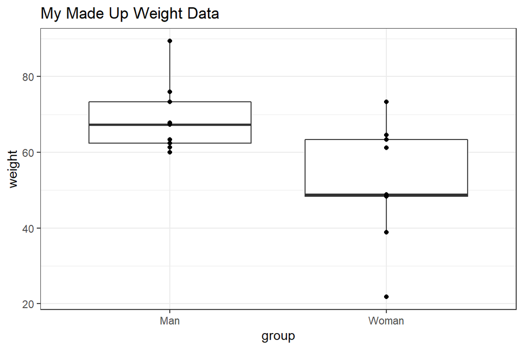

```r
ggplot(weight_data, aes(x = group, y = weight))+
  geom_boxplot()+geom_point()+theme_bw()+
  ggtitle("My Made Up Weight Data")
```

## Scope of this workshop

- We are going to focus on reading data, modifying data, and plotting data today
- Importantly, there are too many considerations to discuss when selecting statistical tests
  - Statistics will be a future workshop topic
  - You can message DVAC on our Slack with statistics questions (using R or otherwise)
- We are going to bypass several key fundamentals of R programming
  - Skip features you won’t need right away
  - Get you straight to working with and plotting **your data**
- If you want to continue learning R, checkout the Github page (https://github.com/taustinn11/DVAC_Nov_2020_intro_R_and_ggplot)
  - Start with files/links immediately found in additional_resources/ folder
  - Follow this with the files/links in additional_resources/extra/

## What does object-oriented mean?

- In R, data are stored as ‘objects’ and have ‘data types’
  - ‘Data types’ are the kind of value a data point is
    - Age (e.g. 26) is “numeric” while Name (e.g. “Austin”) is of type “character”
  - An ‘object’ is data that is organized into a structure and assigned a name
    - A single value, a vector of values, a 2D table (data frame or a matrix), a list, etc
    - I could combine the Age and Name variables into a data frame and name it zoom_meeting_table

```r
Age <- c(26, 24, 26)
Name <- c("Austin", "Jess", "Logan")
zoom_meeting_table <- data.frame(Name, Age)
zoom_meeting_table
```

```
##     Name Age
## 1 Austin  26
## 2   Jess  24
## 3  Logan  26
```

## What are the data objects in R

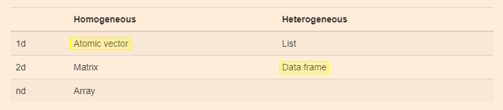

- We are going to primarily use **data frames and vectors**
  - This represents ‘tabular’ data aka data in table form
  - It is most similar to what you would organize in Microsoft Excel

## What are the data objects in R

```r
head(weight_data, 4)
```

```
##   group weight
## 1 Woman   38.9
## 2 Woman   61.2
## 3 Woman   73.3
## 4 Woman   21.8
```

```r
class(weight_data)
```

```
## [1] "data.frame"
```

```r
class(weight_data$group); class(weight_data$weight)
```

```
## [1] "character"
```

```
## [1] "numeric"
```

## A Quick Note about Tidy Data

- Briefly, tidy data is a principle by which you try to record your data and keep it in “tidy” format
  - Being tidy means that each variable has its own column and isn’t spread unnecessarily
    - https://vita.had.co.nz/papers/tidy-data.pdf
  - This workshop is going to operate under the assumption that **you will put in tidy data**. You can clean untidy data, but to do so is beyond the scope of this workshop
  - I’ve included an example of what untidy vs tidy data looks like:

## Tidy Data Example

[figure not shown]

Let’s start the live coding demo!

## Citations

Some citations in text

Gentleman, R. C., Carey, V. J., Bates, D. M., Bolstad, B., Dettling, M., Dudoit, S., Ellis, B., Gautier, L., Ge, Y., Gentry, J., Hornik, K., Hothorn, T., Huber, W., Iacus, S., Irizarry, R., Leisch, F., Li, C., Maechler, M., Rossini, A. J., Sawitzki, G., … Zhang, J. (2004). Bioconductor: open software development for computational biology and bioinformatics. Genome biology, 5(10), R80. https://doi.org/10.1186/gb-2004-5-10-r80